# Sparkify Project Workspace

This workspace contains a tiny subset (128MB) of the full dataset available (12GB). Feel free to use this workspace to build your project, or to explore a smaller subset with Spark before deploying your cluster on the cloud. Instructions for setting up your Spark cluster is included in the last lesson of the Extracurricular Spark Course content.

You can follow the steps below to guide your data analysis and model building portion of this project.

```python
!ls -ltr
```

```
total 126172
-rw-r--r-- 1 root root 128477301 Dec 15  2018 mini_sparkify_event_data.json
-rw-r--r-- 1 root root      4824 Jul 31 09:13 Sparkify-zh.ipynb
drwxr-xr-x 2 root root     57344 Jan  2 14:56 final_data_model.csv
-rw-r--r-- 1 root root    513317 Jan  2 15:43 Sparkify.ipynb
```

```python
# import libraries
import numpy as np
import pandas as pd
import matplotlib.pyplot as plt
import statsmodels.api as sm
%matplotlib inline
from pyspark.sql import SparkSession, Window
from pyspark.sql.functions import avg, col, concat,count, desc, explode, lit, min, max, split, stddev, udf, countDistinct
from pyspark.sql.types import IntegerType, StringType


from pyspark.ml import Pipeline
from pyspark.ml.classification import LogisticRegression, DecisionTreeClassifier, GBTClassifier
from pyspark.ml.evaluation import MulticlassClassificationEvaluator, RegressionEvaluator
from pyspark.ml.feature import CountVectorizer, IDF, Normalizer, PCA, RegexTokenizer, StandardScaler, StopWordsRemover, StringIndexer, VectorAssembler
from pyspark.ml.regression import LinearRegression
from pyspark.ml.tuning import CrossValidator, ParamGridBuilder, TrainValidationSplit
from pyspark.ml import Pipeline
from pyspark.ml.evaluation import MulticlassClassificationEvaluator


import re
import seaborn as sns

# import datetime for parsing datetime object
import datetime

from time import time
```

```python
# create a Spark session
spark = SparkSession.builder \
    .master("local") \
    .appName("Capstone_prj") \
    .getOrCreate()
```

```python
sc = spark.sparkContext
```

```python
sc.getConf().getAll()
```

```
[('spark.master', 'local'),
 ('spark.driver.port', '45223'),
 ('spark.app.id', 'local-1578048419793'),
 ('spark.app.name', 'Capstone_prj'),
 ('spark.driver.host', '7c246275ffc0'),
 ('spark.rdd.compress', 'True'),
 ('spark.serializer.objectStreamReset', '100'),
 ('spark.executor.id', 'driver'),
 ('spark.submit.deployMode', 'client'),
 ('spark.ui.showConsoleProgress', 'true')]
```

# Load and Clean Dataset

In this workspace, the mini-dataset file is `mini_sparkify_event_data.json`. Load and clean the dataset, checking for invalid or missing data - for example, records without userids or sessionids.

```python
user_log = spark.read.json("mini_sparkify_event_data.json")
user_log.persist()
```

```
DataFrame[artist: string, auth: string, firstName: string, gender: string, itemInSession: bigint, lastName: string, length: double, level: string, location: string, method: string, page: string, registration: bigint, sessionId: bigint, song: string, status: bigint, ts: bigint, userAgent: string, use…
```

```python
user_log.show(n=1)
```

```
+--------------+---------+---------+------+-------------+--------+---------+-----+---------------+------+--------+-------------+---------+---------+------+-------------+--------------------+------+
|        artist|     auth|firstName|gender|itemInSession|lastName|   length|level|       location|method|    page| registration|sessionId|     song|status|           ts|           userAgent|userId|
+--------------+---------+---------+------+-------------+--------+---------+-----+---------------+------+--------+-------------+---------+---------+------+-------------+--------------------+------+
|Martha Tilston|Logged In|    Colin|     M|           50| Freeman|277.89016| paid|Bakersfield, CA|   PUT|NextSong|1538173362000|       29|Rockpools|   200|1538352117000|Mozilla/5.0 (Wind...|    30|
+--------------+---------+---------+------+-------------+--------+---------+-----+---------------+------+--------+-------------+---------+---------+------+-------------+--------------------+------+
only showing top 1 row
```

```python
user_log.printSchema()
```

```
root
 |-- artist: string (nullable = true)
 |-- auth: string (nullable = true)
 |-- firstName: string (nullable = true)
 |-- gender: string (nullable = true)
 |-- itemInSession: long (nullable = true)
 |-- lastName: string (nullable = true)
 |-- length: double (nullable = true)
 |-- level: string (nullable = true)
 |-- location: string (nullable = true)
 |-- method: string (nullable = true)
 |-- page: string (nullable = true)
 |-- registration: long (nullable = true)
 |-- sessionId: long (nullable = true)
 |-- song: string (nullable = true)
 |-- status: long (nullable = true)
 |-- ts: long (nullable = true)
 |-- userAgent: string (nullable = true)
 |-- userId: string (nullable = true)
```

# Exploratory Data Analysis

When you're working with the full dataset, perform EDA by loading a small subset of the data and doing basic manipulations within Spark. In this workspace, you are already provided a small subset of data you can explore.

### Data Claening

```
1. Drop NA's.
2. Remove rows with empty as UserId.
```

```python
print(f'Total number of rows: {user_log.count()}')
```

```
Total number of rows: 286500
```

First, clean the dataset, checking for invalid or missing data. For example, records without userids or sessionids.

```python
#drop NA's
user_log_valid = user_log.dropna(how = 'any', subset = ['userId', 'sessionId'])
```

After dropping missing values, check if any missing userId is actually represented by an empty string. A record with empty userId might be generated when the user didn't log in or havn't signed up yet. Therefore, we drop these rows with empty string as userId.

```python
# check 'userId' column if it has empty string value
user_log_valid.select('userId').dropDuplicates().sort('userId').show(5)
```

```
+------+
|userId|
+------+
|      |
|    10|
|   100|
|100001|
|100002|
+------+
only showing top 5 rows
```

```python
# drop empty strings
user_log_valid = user_log_valid.filter(user_log_valid['userId'] != '')
```

```python
df_pd = user_log_valid.toPandas()
df_pd.head()
```

|  | artist | auth | firstName | gender | itemInSession | lastName | length | level | location | method | page | registration | sessionId | song | status | ts | userAgent | userId |
| --- | --- | --- | --- | --- | --- | --- | --- | --- | --- | --- | --- | --- | --- | --- | --- | --- | --- | --- |
| 0 | Martha Tilston | Logged In | Colin | M | 50 | Freeman | 277.89016 | paid | Bakersfield, CA | PUT | NextSong | 1538173362000 | 29 | Rockpools | 200 | 1538352117000 | Mozilla/5.0 (Windows NT 6.1; WOW64; rv:31.0) G... | 30 |
| 1 | Five Iron Frenzy | Logged In | Micah | M | 79 | Long | 236.09424 | free | Boston-Cambridge-Newton, MA-NH | PUT | NextSong | 1538331630000 | 8 | Canada | 200 | 1538352180000 | "Mozilla/5.0 (Windows NT 6.1; WOW64) AppleWebK... | 9 |
| 2 | Adam Lambert | Logged In | Colin | M | 51 | Freeman | 282.82730 | paid | Bakersfield, CA | PUT | NextSong | 1538173362000 | 29 | Time For Miracles | 200 | 1538352394000 | Mozilla/5.0 (Windows NT 6.1; WOW64; rv:31.0) G... | 30 |
| 3 | Enigma | Logged In | Micah | M | 80 | Long | 262.71302 | free | Boston-Cambridge-Newton, MA-NH | PUT | NextSong | 1538331630000 | 8 | Knocking On Forbidden Doors | 200 | 1538352416000 | "Mozilla/5.0 (Windows NT 6.1; WOW64) AppleWebK... | 9 |
| 4 | Daft Punk | Logged In | Colin | M | 52 | Freeman | 223.60771 | paid | Bakersfield, CA | PUT | NextSong | 1538173362000 | 29 | Harder Better Faster Stronger | 200 | 1538352676000 | Mozilla/5.0 (Windows NT 6.1; WOW64; rv:31.0) G... | 30 |

```python
len(df_pd)
```

```
278154
```

### Define Churn

Once you've done some preliminary analysis, create a column `Churn` to use as the label for your model. I suggest using the `Cancellation Confirmation` events to define your churn, which happen for both paid and free users.

This event happens for both paid and free users, meaning that their account associated with us was terminated at the time. When also kept in track of a downgrade event, labeled as Submit Downgrade in activity log.

```python
# create downgrade label flag
flag_downgrade_event = udf(lambda x: 1 if x == "Submit Downgrade" else 0, IntegerType())
user_log_valid = user_log_valid.withColumn("downgrade_event", flag_downgrade_event("page"))

# label user who've ever downgraded
windowval = Window.partitionBy('userId')
user_log_valid = user_log_valid.withColumn('downgrade', max('downgrade_event').over(windowval))

# create churn label
flag_churn_event = udf(lambda x: 1 if x == 'Cancellation Confirmation' else 0, IntegerType())
user_log_valid = user_log_valid.withColumn('churn_event', flag_churn_event('page'))

# label user who churned
windowval = Window.partitionBy('userId')
user_log_valid = user_log_valid.withColumn('churn', max('churn_event').over(windowval))
```

```python
user_log_valid.select(['userId', 'churn', 'downgrade']).dropDuplicates().show(10)
```

```
+------+-----+---------+
|userId|churn|downgrade|
+------+-----+---------+
|100010|    0|        0|
|200002|    0|        0|
|   125|    1|        0|
|   124|    0|        0|
|    51|    1|        0|
|     7|    0|        0|
|    15|    0|        0|
|    54|    1|        1|
|   155|    0|        0|
|100014|    1|        0|
+------+-----+---------+
only showing top 10 rows
```

```python
#count the number of churn levels
user_log_valid.groupBy("churn").agg(count('userId')).show()
```

```
+-----+-------------+
|churn|count(userId)|
+-----+-------------+
|    1|        44864|
|    0|       233290|
+-----+-------------+
```

```python
#count the number of downgrade levels
user_log_valid.groupBy("downgrade").agg(count('userId')).show()
```

```
+---------+-------------+
|downgrade|count(userId)|
+---------+-------------+
|        1|       106652|
|        0|       171502|
+---------+-------------+
```

```python
# transform the event_time & registration_time columns to a more human readable format by creating new columns
convert_ts = udf(lambda x: datetime.datetime.fromtimestamp(x / 1000.0).strftime("%Y-%m-%d %H:%M:%S"))
user_log_valid = user_log_valid.withColumn('event_time', convert_ts('ts'))
user_log_valid = user_log_valid.withColumn('registration_time', convert_ts('registration'))
```

```python
user_log_valid.select(['userId','event_time', 'ts','registration_time', 'registration']).dropDuplicates().show(10)
```

```
+------+-------------------+-------------+-------------------+-------------+
|userId|         event_time|           ts|  registration_time| registration|
+------+-------------------+-------------+-------------------+-------------+
|    30|2018-10-01 02:25:37|1538360737000|2018-09-28 22:22:42|1538173362000|
|    25|2018-10-01 06:51:07|1538376667000|2018-09-07 02:24:59|1536287099000|
|    95|2018-10-01 08:10:43|1538381443000|2018-09-29 09:03:52|1538211832000|
|   126|2018-10-01 09:57:50|1538387870000|2018-09-29 13:23:28|1538227408000|
|   126|2018-10-01 11:16:38|1538392598000|2018-09-29 13:23:28|1538227408000|
|    59|2018-10-01 11:19:28|1538392768000|2018-09-25 15:47:17|1537890437000|
|    95|2018-10-01 11:24:10|1538393050000|2018-09-29 09:03:52|1538211832000|
|   146|2018-10-01 13:26:45|1538400405000|2018-09-05 09:01:13|1536138073000|
|   146|2018-10-01 13:49:55|1538401795000|2018-09-05 09:01:13|1536138073000|
|   131|2018-10-01 14:12:03|1538403123000|2018-08-01 05:45:30|1533102330000|
+------+-------------------+-------------+-------------------+-------------+
only showing top 10 rows
```

```python
user_log_valid.groupBy("userId").agg(countDistinct("ts")).show()
```

```
+------+------------------+
|userId|count(DISTINCT ts)|
+------+------------------+
|100010|               377|
|200002|               473|
|   125|                10|
|    51|              2463|
|   124|              4814|
|     7|               201|
|    54|              3432|
|    15|              2275|
|   155|              1002|
|   132|              2299|
|100014|               309|
|   154|               118|
|   101|              2147|
|    11|               841|
|   138|              2431|
|300017|              4423|
|    29|              3593|
|    69|              1342|
|100021|               319|
|    42|              4254|
+------+------------------+
only showing top 20 rows
```

### Explore Data

Once you've defined churn, perform some exploratory data analysis to observe the behavior for users who stayed vs users who churned. You can start by exploring aggregates on these two groups of users, observing how much of a specific action they experienced per a certain time unit or number of songs played.

```python
#distinct activities
user_log_valid.select('page').dropDuplicates().show()
print("")
print(f'A total number of activities that may users have: {user_log_valid.select("page").dropDuplicates().count()}')
```

```
+--------------------+
|                page|
+--------------------+
|              Cancel|
|    Submit Downgrade|
|         Thumbs Down|
|                Home|
|           Downgrade|
|         Roll Advert|
|              Logout|
|       Save Settings|
|Cancellation Conf...|
|               About|
|            Settings|
|     Add to Playlist|
|          Add Friend|
|            NextSong|
|           Thumbs Up|
|                Help|
|             Upgrade|
|               Error|
|      Submit Upgrade|
+--------------------+


A total number of activities that may users have: 19
```

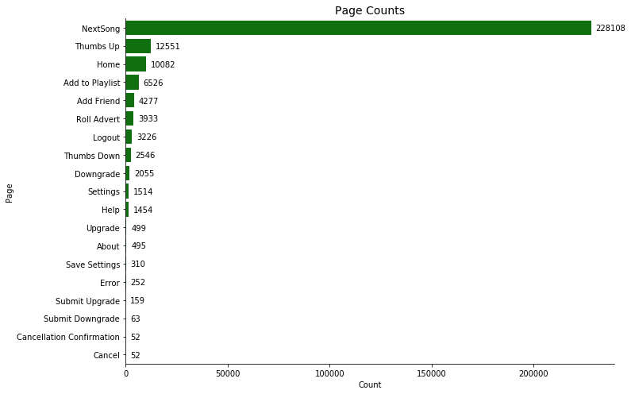

```python
# Retrieve and plot counts of page activities
page_counts = pd.DataFrame(user_log_valid.groupBy('page').count().collect(), columns=["page", "page_count"]).\
                            sort_values(by='page_count', ascending=False).reset_index()

# Instantiate plot
fig, ax = plt.subplots(1, 1, figsize=(11, 7))

# Plot bar chart
sns.barplot(data=page_counts, y='page', x='page_count', ax=ax, color='green')

# Annotate with count values
max_count = page_counts['page_count'].max()
for i, v in page_counts.iterrows():
    label = v.page_count
    ax.text(v.page_count+(max_count*0.01), i+0.15, label, color='black')

# Format chart
ax.set_ylabel("Page")
ax.set_xlabel("Count")
ax.set_title("Page Counts", fontsize=14)

ax.spines['top'].set_visible(False)
ax.spines['right'].set_visible(False)

plt.tight_layout()
plt.show()
```

```python
# User lifetime journy
lifetime_pd = user_log_valid.where('page == "NextSong" OR page == "Thumbs Up"').groupby(['userId', 'churn', 'gender', 'page']).count().toPandas()
lifetime_pd = lifetime_pd.pivot_table(index=['userId','churn','gender'], values='count', columns='page').reset_index()
```

```python
lifetime_pd.head()
```

| page | userId | churn | gender | NextSong | Thumbs Up |
| --- | --- | --- | --- | --- | --- |
| 0 | 10 | 0 | M | 673.0 | 37.0 |
| 1 | 100 | 0 | M | 2682.0 | 148.0 |
| 2 | 100001 | 1 | F | 133.0 | 8.0 |
| 3 | 100002 | 0 | F | 195.0 | 5.0 |
| 4 | 100003 | 1 | F | 51.0 | 3.0 |

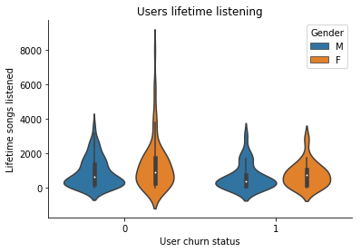

```python
ax = sns.violinplot(data=lifetime_pd, x='churn', y='NextSong', hue='gender')
plt.xlabel('User churn status')
plt.ylabel('Lifetime songs listened')
plt.legend(title='Gender', loc='best')
plt.title('Users lifetime listening')
sns.despine(ax=ax);
```

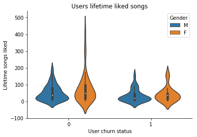

```python
ax = sns.violinplot(data=lifetime_pd, x='churn', y='Thumbs Up', hue='gender')
plt.xlabel('User churn status')
plt.ylabel('Lifetime songs liked')
plt.legend(title='Gender', loc='best')
plt.title('Users lifetime liked songs')
sns.despine(ax=ax);
```

From the above two violin plot suggest that behavior of users acroos the churn status does not vary much.

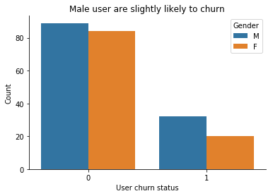

```python
gender_churn_pd = user_log_valid.dropDuplicates(["userId", "gender"]).groupby(["churn", "gender"]).count().sort("churn").toPandas()

ax = sns.barplot(x='churn', y='count', hue='gender', data=gender_churn_pd)
plt.xlabel('User churn status')
plt.ylabel('Count')
plt.legend(title='Gender', loc='best')
plt.title('Male user are slightly likely to churn')
sns.despine(ax=ax);
```

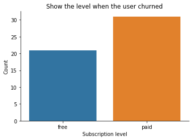

```python
df_pd = user_log_valid.filter(user_log_valid.page=="Cancellation Confirmation").groupby("level").count().toPandas()
ax = sns.barplot(x="level", y="count", data=df_pd)
plt.xlabel('Subscription level')
plt.ylabel('Count')
plt.title('Show the level when the user churned')
sns.despine(ax=ax);
```

Show the distribution in operations in each session

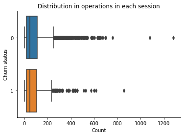

```python
df_pd = user_log_valid.groupby("churn", "userId", "sessionId").count().toPandas()
ax = sns.boxplot(x='count', y='churn', orient="h", data=df_pd)
plt.xlabel('Count')
plt.ylabel('Churn status')
plt.title('Distribution in operations in each session')
sns.despine(ax=ax);
```

```python
user_log_valid.printSchema()
```

```
root
 |-- artist: string (nullable = true)
 |-- auth: string (nullable = true)
 |-- firstName: string (nullable = true)
 |-- gender: string (nullable = true)
 |-- itemInSession: long (nullable = true)
 |-- lastName: string (nullable = true)
 |-- length: double (nullable = true)
 |-- level: string (nullable = true)
 |-- location: string (nullable = true)
 |-- method: string (nullable = true)
 |-- page: string (nullable = true)
 |-- registration: long (nullable = true)
 |-- sessionId: long (nullable = true)
 |-- song: string (nullable = true)
 |-- status: long (nullable = true)
 |-- ts: long (nullable = true)
 |-- userAgent: string (nullable = true)
 |-- userId: string (nullable = true)
 |-- downgrade_event: integer (nullable = true)
 |-- downgrade: integer (nullable = true)
 |-- churn_event: integer (nullable = true)
 |-- churn: integer (nullable = true)
 |-- event_time: string (nullable = true)
 |-- registration_time: string (nullable = true)
```

```python
location_count= user_log_valid.select('userId','location', 'level')\
                .groupby('location', 'level').count().toPandas().sort_values(by='count')
```

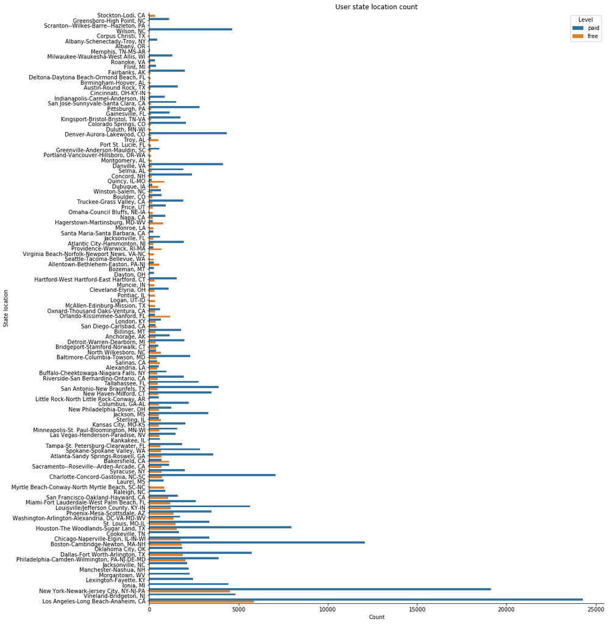

```python
plt.figure(figsize=(15,20))
ax = sns.barplot(x='count', y='location', hue='level', data=location_count)
plt.xlabel('Count')
plt.ylabel('State location')
plt.legend(title='Level', loc='best')
plt.title('User state location count')
sns.despine(ax=ax);
```

**Device used**

```python
device_udf = udf(lambda x: str(re.findall(r'\((.*?)\)', x)[0].split(";")[0]\
                               .split()[0]) if x is not None else None, StringType())
```

```python
user_log_valid = user_log_valid.withColumn("device", device_udf(user_log_valid.userAgent))
```

```python
df_device = user_log_valid.groupBy("device").agg(countDistinct("UserId")\
                                                   .alias("count")).sort(col("count").desc()).toPandas()
```

```python
df_device.head()
```

|  | device | count |
| --- | --- | --- |
| 0 | Windows | 106 |
| 1 | Macintosh | 86 |
| 2 | iPhone | 13 |
| 3 | X11 | 12 |
| 4 | compatible | 5 |

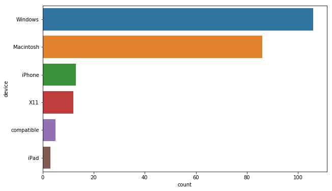

```python
g = sns.barplot(ax=ax, x="count", y="device", data=df_device)
plt.show()
```

```python
df_device_chr = user_log_valid.groupBy("device", "churn")\
            .agg(countDistinct("UserId").alias("count")).sort(col("count").desc()).toPandas()
```

```python
df_device_chr.head()
```

|  | device | churn | count |
| --- | --- | --- | --- |
| 0 | Windows | 0 | 82 |
| 1 | Macintosh | 0 | 67 |
| 2 | Windows | 1 | 24 |
| 3 | Macintosh | 1 | 19 |
| 4 | iPhone | 0 | 9 |

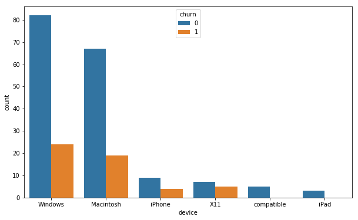

```python
fig, ax = plt.subplots(figsize=(10,6))

g = sns.barplot(ax=ax, x="device", y="count", hue="churn", data=df_device_chr)
plt.show()
```

```python
user_log_valid.toPandas().describe()
```

|  | itemInSession | length | registration | sessionId | status | ts | downgrade_event | downgrade | churn_event | churn |
| --- | --- | --- | --- | --- | --- | --- | --- | --- | --- | --- |
| count | 278154.000000 | 228108.000000 | 2.781540e+05 | 278154.000000 | 278154.000000 | 2.781540e+05 | 278154.000000 | 278154.000000 | 278154.000000 | 278154.000000 |
| mean | 114.899182 | 249.117182 | 1.535359e+12 | 1042.561624 | 209.103216 | 1.540959e+12 | 0.000226 | 0.383428 | 0.000187 | 0.161292 |
| std | 129.851729 | 99.235179 | 3.291322e+09 | 726.501036 | 30.151389 | 1.506829e+09 | 0.015048 | 0.486222 | 0.013672 | 0.367801 |
| min | 0.000000 | 0.783220 | 1.521381e+12 | 1.000000 | 200.000000 | 1.538352e+12 | 0.000000 | 0.000000 | 0.000000 | 0.000000 |
| 25% | 27.000000 | 199.888530 | 1.533522e+12 | 338.000000 | 200.000000 | 1.539699e+12 | 0.000000 | 0.000000 | 0.000000 | 0.000000 |
| 50% | 70.000000 | 234.500770 | 1.536664e+12 | 1017.000000 | 200.000000 | 1.540934e+12 | 0.000000 | 0.000000 | 0.000000 | 0.000000 |
| 75% | 157.000000 | 277.158730 | 1.537672e+12 | 1675.000000 | 200.000000 | 1.542268e+12 | 0.000000 | 1.000000 | 0.000000 | 0.000000 |
| max | 1321.000000 | 3024.665670 | 1.543247e+12 | 2474.000000 | 404.000000 | 1.543799e+12 | 1.000000 | 1.000000 | 1.000000 | 1.000000 |

# Feature Engineering

Once you've familiarized yourself with the data, build out the features you find promising to train your model on. To work with the full dataset, you can follow the following steps.

- Write a script to extract the necessary features from the smaller subset of data
- Ensure that your script is scalable, using the best practices discussed in Lesson 3
- Try your script on the full data set, debugging your script if necessary

If you are working in the classroom workspace, you can just extract features based on the small subset of data contained here. Be sure to transfer over this work to the larger dataset when you work on your Spark cluster.

**Feature 1: Time length since the user registered is the first feature we will first as it may reflect the user engagement, loyality, and etc**

```python
# Time since registration
time_len = user_log_valid \
    .select('userId','registration','ts') \
    .withColumn('lifetime',(user_log_valid.ts-user_log_valid.registration)) \
    .groupBy('userId') \
    .agg({'lifetime':'max'}) \
    .withColumnRenamed('max(lifetime)','lifetime') \
    .select('userId', (col('lifetime')/1000/3600/24).alias('lifetime'))
time_len.describe().show()
```

```
+-------+------------------+-------------------+
|summary|            userId|           lifetime|
+-------+------------------+-------------------+
|  count|               225|                225|
|   mean|65391.013333333336|   79.8456834876543|
| stddev|105396.47791907164|  37.66147001861254|
|    min|                10|0.31372685185185184|
|    max|                99|  256.3776736111111|
+-------+------------------+-------------------+
```

**Feature 2: Demographic information from gender**

```python
# Gender
gender = user_log_valid \
    .select("userId", "gender") \
    .dropDuplicates() \
    .replace(['M', 'F'], ['0', '1'], 'gender') \
    .select('userId', col('gender').cast('int'))
gender.describe().show()
```

```
+-------+------------------+-------------------+
|summary|            userId|             gender|
+-------+------------------+-------------------+
|  count|               225|                225|
|   mean|65391.013333333336| 0.4622222222222222|
| stddev|105396.47791907165|0.49968243883744773|
|    min|                10|                  0|
|    max|                99|                  1|
+-------+------------------+-------------------+
```

**Feature 3: Now we will look at total song listen by each user. The more user use tend to stay with in the service**

```python
# Total songs listened
tot_song = user_log_valid \
    .select('userID','song') \
    .groupBy('userID') \
    .count() \
    .withColumnRenamed('count', 'total_songs')
tot_song.describe().show()
```

```
+-------+------------------+-----------------+
|summary|            userID|      total_songs|
+-------+------------------+-----------------+
|  count|               225|              225|
|   mean|65391.013333333336|          1236.24|
| stddev|105396.47791907164|1329.531716432519|
|    min|                10|                6|
|    max|                99|             9632|
+-------+------------------+-----------------+
```

**Feature 4: Next feature is about song/service quality and user engagement (numbers of thumbs up and down).**

```python
# Number of Thumbs-Up
thumbs_up = user_log_valid \
    .select('userID','page') \
    .where(user_log_valid.page == 'Thumbs Up') \
    .groupBy('userID') \
    .count() \
    .withColumnRenamed('count', 'num_thumb_up')
thumbs_up.describe().show()
```

```
+-------+------------------+-----------------+
|summary|            userID|     num_thumb_up|
+-------+------------------+-----------------+
|  count|               220|              220|
|   mean| 66420.27727272727|            57.05|
| stddev|106196.51156121881|65.67028650524044|
|    min|                10|                1|
|    max|                99|              437|
+-------+------------------+-----------------+
```

```python
# Number of Thumbs-Down
thumbs_down = user_log_valid \
    .select('userID','page') \
    .where(user_log_valid.page == 'Thumbs Down') \
    .groupBy('userID') \
    .count() \
    .withColumnRenamed('count', 'num_thumb_down')
thumbs_down.describe().show()
```

```
+-------+------------------+------------------+
|summary|            userID|    num_thumb_down|
+-------+------------------+------------------+
|  count|               203|               203|
|   mean| 66066.16256157635|12.541871921182265|
| stddev|106108.32569893777|13.198108566983787|
|    min|                10|                 1|
|    max|                99|                75|
+-------+------------------+------------------+
```

**Feature 5: The next feature is about user adding song to their playlist.**

```python
# Number of songs added to playlist
playlist = user_log_valid \
    .select('userID','page') \
    .where(user_log_valid.page == 'Add to Playlist') \
    .groupBy('userID') \
    .count() \
    .withColumnRenamed('count', 'add_to_playlist')
playlist.describe().show()
```

```
+-------+------------------+-----------------+
|summary|            userID|  add_to_playlist|
+-------+------------------+-----------------+
|  count|               215|              215|
|   mean| 66103.63720930232|30.35348837209302|
| stddev|106360.47999565038| 32.8520568555997|
|    min|                10|                1|
|    max|                99|              240|
+-------+------------------+-----------------+
```

**Feature 6: How many singers have the user heard.**

```python
user_artist_count = user_log_valid \
        .filter(user_log_valid.page == "NextSong") \
        .select("userId", "artist") \
        .dropDuplicates().groupby("userId").count() \
        .withColumnRenamed("count", "aritstCount")
user_artist_count.describe().show()
```

```
+-------+------------------+-----------------+
|summary|            userId|      aritstCount|
+-------+------------------+-----------------+
|  count|               225|              225|
|   mean|65391.013333333336|696.3777777777777|
| stddev|105396.47791907164|603.9518698630802|
|    min|                10|                3|
|    max|                99|             3544|
+-------+------------------+-----------------+
```

**Feature 7: The next feature is the length of listening, serving the same objective as the total number of songs listened.**

```python
# Total length of listening
len_listen = user_log_valid \
    .select('userID','length') \
    .groupBy('userID') \
    .sum() \
    .withColumnRenamed('sum(length)', 'listen_time')
len_listen.describe().show()
```

```
+-------+------------------+------------------+
|summary|            userID|       listen_time|
+-------+------------------+------------------+
|  count|               225|               225|
|   mean|65391.013333333336|252558.32065155543|
| stddev|105396.47791907164| 275396.4038847635|
|    min|                10|         691.66884|
|    max|                99|1991154.9155799907|
+-------+------------------+------------------+
```

**Feature 8: Next feature is avg & min & max time per session**

```python
user_session_time = user_log_valid.groupby("userId", "sessionId")\
                    .agg(((max(user_log_valid.ts)-min(user_log_valid.ts))/(1000*60))\
                    .alias("sessionTime"))
```

```python
user_session_time_stat = user_session_time.groupby("userId")\
            .agg(avg(user_session_time.sessionTime)\
                 .alias("avgSessionTime"), min(user_session_time.sessionTime)\
                 .alias("minSessionTime"), max(user_session_time.sessionTime)\
                 .alias("maxSessionTime")).sort("userId")
```

```python
user_session_time_stat.describe().show()
```

```
+-------+------------------+------------------+-----------------+-----------------+
|summary|            userId|    avgSessionTime|   minSessionTime|   maxSessionTime|
+-------+------------------+------------------+-----------------+-----------------+
|  count|               225|               225|              225|              225|
|   mean|65391.013333333336|288.16598407334976| 36.1317777777778|968.0325185185189|
| stddev| 105396.4779190716|176.84244472357116|90.64909420429709|723.3177369502857|
|    min|                10|               7.0|              0.0|              7.0|
|    max|                99|            1179.9|904.8666666666667|4455.083333333333|
+-------+------------------+------------------+-----------------+-----------------+
```

**Feature 9: Number of songs per session**

```python
user_session_songs = user_log_valid.filter(user_log_valid.page=="NextSong")\
                    .groupby("userId", "sessionId").count()
```

```python
user_session_songs_avg = user_session_songs.groupby("userId")\
                        .agg(avg(user_session_songs["count"])\
                             .alias("avgSessionSongs")).sort("userId")
```

```python
user_session_songs_avg.describe().show()
```

```
+-------+------------------+-----------------+
|summary|            userId|  avgSessionSongs|
+-------+------------------+-----------------+
|  count|               225|              225|
|   mean|65391.013333333336|70.78971233958936|
| stddev| 105396.4779190716|42.61536975438169|
|    min|                10|              3.0|
|    max|                99|286.6666666666667|
+-------+------------------+-----------------+
```

**Feature 10: Churn status**

```python
# Churn status
label = user_log_valid \
    .select('userId', col('churn').alias('label')) \
    .dropDuplicates()
label.describe().show()
```

```
+-------+------------------+------------------+
|summary|            userId|             label|
+-------+------------------+------------------+
|  count|               225|               225|
|   mean|65391.013333333336|0.2311111111111111|
| stddev|105396.47791907164|0.4224832108996327|
|    min|                10|                 0|
|    max|                99|                 1|
+-------+------------------+------------------+
```

```python
# put all the features dataframe into a list
features_list = []
features_list.append(time_len)
features_list.append(gender)
features_list.append(tot_song)
features_list.append(thumbs_up)
features_list.append(thumbs_down)
features_list.append(playlist)
features_list.append(len_listen)
features_list.append(user_session_time_stat)
features_list.append(user_session_songs_avg)
features_list.append(label)
```

```python
data = time_len.join(gender,'userID','outer') \
    .join(tot_song,'userID','outer') \
    .join(thumbs_up,'userID','outer') \
    .join(thumbs_down,'userID','outer') \
    .join(user_artist_count,'userID','outer') \
    .join(playlist,'userID','outer') \
    .join(len_listen,'userID','outer') \
    .join(user_session_time_stat,'userID','outer') \
    .join(user_session_songs_avg,'userID','outer') \
    .join(label,'userID','outer') \
    .fillna(0)
```

```python
# sort and view the final dataframe
data = data.sort("userId")
data.persist()
data.show(5)
```

```
+------+------------------+------+-----------+------------+--------------+-----------+---------------+------------------+------------------+-----------------+------------------+------------------+-----+
|userId|          lifetime|gender|total_songs|num_thumb_up|num_thumb_down|aritstCount|add_to_playlist|       listen_time|    avgSessionTime|   minSessionTime|    maxSessionTime|   avgSessionSongs|label|
+------+------------------+------+-----------+------------+--------------+-----------+---------------+------------------+------------------+-----------------+------------------+------------------+-----+
|    10| 51.76265046296297|     0|        795|          37|             4|        565|              9|166866.37251000004|459.74722222222226|91.41666666666667|1547.9166666666667|112.16666666666667|    0|
|   100| 64.87377314814815|     0|       3214|         148|            27|       1705|             61|  672877.856590001| 316.5190476190476|              0.0|1019.5833333333334| 78.88235294117646|    0|
|100001| 44.80021990740741|     1|        187|           8|             2|        125|              3|35073.742150000005|148.15833333333333|             63.0|215.28333333333333|             33.25|    1|
|100002|160.47207175925925|     1|        218|           5|             0|        184|              5| 49559.91809999999|201.18333333333334|              0.0| 730.4666666666667|             48.75|    0|
|100003|22.748113425925926|     1|         78|           3|             0|         50|              2|12306.419320000003| 99.11666666666667|3.216666666666667|195.01666666666668|              25.5|    1|
+------+------------------+------+-----------+------------+--------------+-----------+---------------+------------------+------------------+-----------------+------------------+------------------+-----+
only showing top 5 rows
```

```python
data.printSchema()
```

```
root
 |-- userId: string (nullable = true)
 |-- lifetime: double (nullable = false)
 |-- gender: integer (nullable = true)
 |-- total_songs: long (nullable = true)
 |-- num_thumb_up: long (nullable = true)
 |-- num_thumb_down: long (nullable = true)
 |-- aritstCount: long (nullable = true)
 |-- add_to_playlist: long (nullable = true)
 |-- listen_time: double (nullable = false)
 |-- avgSessionTime: double (nullable = false)
 |-- minSessionTime: double (nullable = false)
 |-- maxSessionTime: double (nullable = false)
 |-- avgSessionSongs: double (nullable = false)
 |-- label: integer (nullable = true)
```

```python
data.groupBy("label").count().show()
```

```
+-----+-----+
|label|count|
+-----+-----+
|    1|   52|
|    0|  173|
+-----+-----+
```

**Correlation between features**

```python
numeric_features = ['lifetime','total_songs','num_thumb_up','num_thumb_down',\
                    'add_to_playlist', 'listen_time', 'avgSessionTime', 'minSessionTime',\
                    'maxSessionTime', 'avgSessionSongs','label']
numeric_data = data.select(numeric_features).toPandas()
```

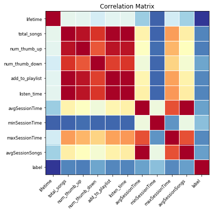

```python
fig, ax = plt.subplots(figsize=(10,6))
corr = numeric_data.corr()
sm.graphics.plot_corr(corr, xnames=list(corr.columns), ax=ax)
plt.show()
```

**Distribution of variables.**

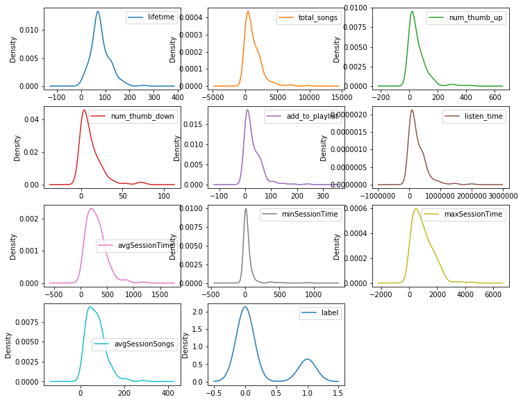

```python
fig, ax = plt.subplots(figsize=(12,10))
numeric_data.plot(kind='density', subplots=True, layout=(4,3), sharex=False, ax=ax)
plt.show()
```

```python
!rm -rf final_data.csv
```

```python
out_path = "final_data.csv"
```

```python
data.write.save(out_path, format="csv", header=True)
```

# Modeling

Split the full dataset into train, test, and validation sets. Test out several of the machine learning methods you learned. Evaluate the accuracy of the various models, tuning parameters as necessary. Determine your winning model based on test accuracy and report results on the validation set. Since the churned users are a fairly small subset, I suggest using F1 score as the metric to optimize.

```python
in_path = "final_data.csv"
```

```python
df_final = spark.read.csv(in_path, inferSchema =True, header=True)
df_final.persist()
```

```
DataFrame[userId: int, lifetime: double, gender: int, total_songs: int, num_thumb_up: int, num_thumb_down: int, aritstCount: int, add_to_playlist: int, listen_time: double, avgSessionTime: double, minSessionTime: double, maxSessionTime: double, avgSessionSongs: double, label: int]
```

Vectorize feature

```python
# Vector assembler
cols = ["lifetime", "gender", "num_thumb_up", \
          'total_songs','num_thumb_up','num_thumb_down','aritstCount','add_to_playlist', \
        'listen_time', 'avgSessionTime', 'minSessionTime', 'maxSessionTime', \
       'avgSessionSongs']
assembler = VectorAssembler(inputCols=cols, outputCol="NumFeatures")
data_final = assembler.transform(df_final)
```

```python
data_final.printSchema()
```

```
root
 |-- userId: integer (nullable = true)
 |-- lifetime: double (nullable = true)
 |-- gender: integer (nullable = true)
 |-- total_songs: integer (nullable = true)
 |-- num_thumb_up: integer (nullable = true)
 |-- num_thumb_down: integer (nullable = true)
 |-- aritstCount: integer (nullable = true)
 |-- add_to_playlist: integer (nullable = true)
 |-- listen_time: double (nullable = true)
 |-- avgSessionTime: double (nullable = true)
 |-- minSessionTime: double (nullable = true)
 |-- maxSessionTime: double (nullable = true)
 |-- avgSessionSongs: double (nullable = true)
 |-- label: integer (nullable = true)
 |-- NumFeatures: vector (nullable = true)
```

```python
# standard scaler
scaler = StandardScaler(inputCol="NumFeatures", outputCol="features", withStd=True)
scalerModel = scaler.fit(data_final)
data_final = scalerModel.transform(data_final)
```

```python
train, test = data_final.randomSplit([0.8, 0.2], seed=42)
```

```python
train.take(5)
```

```
[Row(userId=2, lifetime=69.90317129629629, gender=1, total_songs=899, num_thumb_up=29, num_thumb_down=6, aritstCount=587, add_to_playlist=13, listen_time=188687.38342000003, avgSessionTime=445.0166666666667, minSessionTime=14.75, maxSessionTime=1506.0166666666667, avgSessionSongs=107.85714285714286,…
 Row(userId=14, lifetime=132.54185185185185, gender=0, total_songs=1432, num_thumb_up=54, num_thumb_down=12, aritstCount=904, add_to_playlist=34, listen_time=304778.6487799997, avgSessionTime=457.2636363636364, minSessionTime=38.233333333333334, maxSessionTime=1162.1333333333334, avgSessionSongs=111…
 Row(userId=20, lifetime=77.02128472222222, gender=1, total_songs=2195, num_thumb_up=106, num_thumb_down=21, aritstCount=1216, add_to_playlist=54, listen_time=451089.7797800002, avgSessionTime=392.9087719298246, minSessionTime=0.0, maxSessionTime=1716.4, avgSessionSongs=100.38888888888889, label=0, …
 Row(userId=22, lifetime=61.48951388888889, gender=1, total_songs=40, num_thumb_up=3, num_thumb_down=0, aritstCount=28, add_to_playlist=0, listen_time=7403.8208, avgSessionTime=53.31666666666667, minSessionTime=4.75, maxSessionTime=101.88333333333334, avgSessionSongs=14.0, label=0, NumFeatures=Dense…
 Row(userId=23, lifetime=135.89708333333334, gender=1, total_songs=782, num_thumb_up=28, num_thumb_down=6, aritstCount=553, add_to_playlist=21, listen_time=164815.40200000003, avgSessionTime=682.5541666666667, minSessionTime=29.783333333333335, maxSessionTime=2374.633333333333, avgSessionSongs=164.0…
```

**Logistic Regression**

```python
lr =  LogisticRegression()
paramGrid = ParamGridBuilder() \
    .addGrid(lr.elasticNetParam,[0.0, 0.1, 0.5, 1.0]) \
    .addGrid(lr.regParam,[0.0, 0.05, 0.1]) \
    .build()

crossval = CrossValidator(estimator=lr,
                          estimatorParamMaps=paramGrid,
                          evaluator=MulticlassClassificationEvaluator(),
                          numFolds=3)
```

```python
start = time()
cvModel_lr = crossval.fit(train)
end = time()
print(F'The training process took {end - start} seconds')
```

```
The training process took 334.29432940483093 seconds
```

```python
#!rm -rf cvModel_dt.model/  cvModel_gbt.model/ cvModel_lr.model/
```

```python
cvModel_lr.save('cvModel_lr.model')
```

```python
cvModel_lr.avgMetrics
```

```
[0.7319741524883535,
 0.6996995822975215,
 0.6633267776955427,
 0.7319741524883535,
 0.6996995822975215,
 0.6559035029610187,
 0.7319741524883535,
 0.6807689417902484,
 0.6445753575799862,
 0.7319741524883535,
 0.6559035029610187,
 0.6471961602007889]
```

```python
tvs = TrainValidationSplit(estimator=lr,
                               estimatorParamMaps=paramGrid,
                               evaluator=RegressionEvaluator(),
                               # 80% of the data will be used for training, 20% for validation.
                               trainRatio=0.8)
```

```python
model = tvs.fit(train)
```

```python
# Make predictions on test data. model is the model with combination of parameters
# that performed best.
model.transform(test)\
        .select("features", "label", "prediction")\
        .show()
```

```
+--------------------+-----+----------+
|            features|label|prediction|
+--------------------+-----+----------+
|[6.80742609049534...|    0|       0.0|
|[1.37441927883806...|    0|       0.0|
|[1.93844067761783...|    1|       0.0|
|[2.00329690912741...|    0|       0.0|
|[1.71542779332508...|    0|       1.0|
|[3.27544482646761...|    0|       0.0|
|[1.49303938063440...|    0|       1.0|
|[5.00011768829901...|    1|       0.0|
|[1.96961877455304...|    0|       0.0|
|[2.09681859986628...|    0|       0.0|
|[3.55978192843013...|    0|       0.0|
|[3.53148955410484...|    0|       0.0|
|[1.86189988174703...|    0|       0.0|
|[3.30284228873326...|    0|       0.0|
|[1.84322012909540...|    0|       0.0|
|[2.03629986451393...|    0|       0.0|
|[2.51104149259580...|    0|       0.0|
|[2.71494622196660...|    0|       0.0|
|[3.28004723134580...|    0|       0.0|
|[1.97654512345425...|    0|       0.0|
+--------------------+-----+----------+
only showing top 20 rows
```

**Decision Tree**

```python
dt = DecisionTreeClassifier()
paramGrid = ParamGridBuilder() \
    .addGrid(dt.impurity,['entropy', 'gini']) \
    .addGrid(dt.maxDepth,[2, 3, 4, 5, 6, 7, 8]) \
    .build()

crossval_dt = CrossValidator(estimator=dt,
                          estimatorParamMaps=paramGrid,
                          evaluator=MulticlassClassificationEvaluator(),
                          numFolds=3)
```

```python
start = time()
cvModel_dt = crossval_dt.fit(train)
end = time()
print(F'The training process took {end - start} seconds')
```

```
The training process took 60.08673143386841 seconds
```

```python
cvModel_dt.save('cvModel_dt.model')
```

```python
cvModel_dt.avgMetrics
```

```
[0.7217900834230242,
 0.716461407365286,
 0.7325135992485028,
 0.7017282871826351,
 0.6933949094181607,
 0.6831438212104162,
 0.6876009051480938,
 0.7500396434231562,
 0.760091532389434,
 0.744543290891472,
 0.7119352499429153,
 0.6901440512796767,
 0.6901440512796767,
 0.6850799021632401]
```

**Gradient-Boosted Trees (GBTs)**

```python
gbt = GBTClassifier()

paramGrid = ParamGridBuilder() \
    .addGrid(gbt.maxIter,[3, 10, 20]) \
    .addGrid(gbt.maxDepth,[2, 4, 6, 8]) \
    .build()

crossval_gbt = CrossValidator(estimator=gbt,
                          estimatorParamMaps=paramGrid,
                          evaluator=MulticlassClassificationEvaluator(),
                          numFolds=3)
```

```python
start = time()
cvModel_gbt = crossval_gbt.fit(train)
end = time()
print(F'The training process took {end - start} seconds')
```

```
The training process took 294.6497461795807 seconds
```

```python
cvModel_gbt.save('cvModel_gbt.model')
```

```python
cvModel_gbt.avgMetrics
```

```
[0.7500396434231562,
 0.7346285063492641,
 0.6965222236727798,
 0.6850799021632401,
 0.7500396434231562,
 0.7359207942737773,
 0.7004393792874231,
 0.6850799021632401,
 0.7415871493338179,
 0.7359207942737773,
 0.6901440512796767,
 0.6850799021632401]
```

##### Model Evaluation

```python
def metric_(res):
    tp = res.filter("label = 1 and prediction = 1").count()
    fp = res.filter("label = 0 and prediction = 1").count()
    fn = res.filter("label = 1 and prediction = 0").count()
    tn = res.filter("label = 0 and prediction = 0").count()
    total = res.count()
    accuracy = (1.0*tp + tn) / total
    precision = tp / (tp + fp)
    recall = tp / (tp + fn)
    f1 = 2*precision*recall / (precision+recall)
    print(f'Accuracy: {round(accuracy, 2)}')
    print(f'Precision: {round(precision, 2)}')
    print(f'Recall: {round(recall, 2)}')
    print(f'F1 Score: {round(f1, 2)}')
```

```python
results_lr = cvModel_lr.transform(test)
```

```python
print(results_lr.filter(results_lr.label == results_lr.prediction).count())
print(results_lr.count())
```

```
44
54
```

```python
results_dt = cvModel_dt.transform(test)
```

```python
results_gbt = cvModel_gbt.transform(test)
```

```python
#Logistric_regression
metric_(results_lr)
```

```
Accuracy: 0.81
Precision: 0.5
Recall: 0.4
F1 Score: 0.44
```

```python
#Decision tree
metric_(results_dt)
```

```
Accuracy: 0.83
Precision: 0.55
Recall: 0.6
F1 Score: 0.57
```

```python
#Gradient bo0st
metric_(results_gbt)
```

```
Accuracy: 0.85
Precision: 0.6
Recall: 0.6
F1 Score: 0.6
```

#### Model summary

```
1. The logistic regression model has a accuracy of: 0.81, and F1 score of:0.44, using 334.29 seconds.
2. The decision tree machine model has a accuracy of: 0.83, and F1 score of: 0.57, using 60.08 seconds.
3. The gradient boosted trees model has a accuracy of: 0.85, and F1 score of: 0.6, using 294.64 seconds.
```

GBT model perform the best, we choose GBT model as our final used model and conduct a grid search to fine tune our model this time.

**Hyper parameter tuning**

We use grid search to fine tune our GBT Classifier. We mainly tuned two parameters, maxDepth and maxIter.

```python
GBTClassifier(maxIter=10,seed=42)

# build paramGrid
paramGrid_gbt = ParamGridBuilder() \
    .addGrid(gbt.maxDepth,[5, 10]) \
    .addGrid(gbt.maxIter, [10,15]) \
    .build()

# set evaluator
f1_evaluator = MulticlassClassificationEvaluator(metricName='f1')

crossval_gbt = CrossValidator(estimator=gbt,
                          estimatorParamMaps=paramGrid_gbt,
                          evaluator=f1_evaluator,
                          numFolds=3)
```

```python
cvModel_gbt = crossval_gbt.fit(train)
cvModel_gbt.avgMetrics
```

```
[0.7119352499429153,
 0.7161791793569128,
 0.6850799021632401,
 0.6850799021632401]
```

```python
gbt_best = GBTClassifier(maxIter=10,seed=42, maxDepth=5)
gbt_best_model = gbt_best.fit(train)
results_final = gbt_best_model.transform(test)
```

```python
evaluator = MulticlassClassificationEvaluator(predictionCol="prediction")
```

```python
print('Test set metrics:')
print(f'Accuracy: {evaluator.evaluate(results_final, {evaluator.metricName: "accuracy"})}')
print(f'F-1 Score: {evaluator.evaluate(results_final, {evaluator.metricName: "f1"})}')
```

```
Test set metrics:
Accuracy: 0.8333333333333334
F-1 Score: 0.8298836980090676
```

# Final Steps

Clean up your code, adding comments and renaming variables to make the code easier to read and maintain. Refer to the Spark Project Overview page and Data Scientist Capstone Project Rubric to make sure you are including all components of the capstone project and meet all expectations. Remember, this includes thorough documentation in a README file in a Github repository, as well as a web app or blog post.